# Amir Melnikov Ex3

[figure not shown]

## Exercise 3 - Machine Learning in Python (Classification Example) - By Omer Dembinsky

#### Based on HR Analytics Employee Attrition:

https://www.kaggle.com/giripujar/hr-analytics

```python
import pandas as pd
import numpy as np
import matplotlib.pyplot as plt
import seaborn as sns
from sklearn.preprocessing import OneHotEncoder
from sklearn.model_selection import train_test_split
from sklearn.tree import DecisionTreeClassifier
from sklearn.metrics import confusion_matrix
from sklearn.metrics import precision_score, recall_score
from sklearn.linear_model import LinearRegression
from sklearn.ensemble import RandomForestRegressor
```

## **Basic data exploration**

#### Download and read the data

```python
df = pd.read_csv("HR_comma_sep.csv")
```

#### Examine your data using different methods

Use the head, info function to get a sense of your data.

```python
df.sample(5)
```

|  | satisfaction_level | last_evaluation | number_project | average_montly_hours | time_spend_company | Work_accident | left | promotion_last_5years | Department | salary |
| --- | --- | --- | --- | --- | --- | --- | --- | --- | --- | --- |
| 1672 | 0.84 | 0.83 | 4 | 239 | 5 | 0 | 1 | 0 | product_mng | low |
| 2579 | 0.76 | 0.51 | 4 | 281 | 3 | 0 | 0 | 0 | IT | low |
| 8803 | 0.60 | 0.48 | 4 | 219 | 4 | 1 | 0 | 0 | sales | medium |
| 11607 | 0.77 | 0.68 | 3 | 214 | 8 | 1 | 0 | 0 | management | high |
| 10221 | 0.53 | 0.75 | 4 | 240 | 4 | 0 | 0 | 0 | product_mng | low |

```python
df.info()
```

```
<class 'pandas.core.frame.DataFrame'>
RangeIndex: 14999 entries, 0 to 14998
Data columns (total 10 columns):
 #   Column                 Non-Null Count  Dtype
---  ------                 --------------  -----
 0   satisfaction_level     14999 non-null  float64
 1   last_evaluation        14999 non-null  float64
 2   number_project         14999 non-null  int64
 3   average_montly_hours   14999 non-null  int64
 4   time_spend_company     14999 non-null  int64
 5   Work_accident          14999 non-null  int64
 6   left                   14999 non-null  int64
 7   promotion_last_5years  14999 non-null  int64
 8   Department             14999 non-null  object
 9   salary                 14999 non-null  object
dtypes: float64(2), int64(6), object(2)
memory usage: 1.1+ MB
```

*There are 10 features: 8 numeric and 2 objects.*

*Some of the numeric features seem to be categorical (left, promotion, work accident)

```python
df.describe()
#The describe function is applied to numeric features only:
```

|  | satisfaction_level | last_evaluation | number_project | average_montly_hours | time_spend_company | Work_accident | left | promotion_last_5years |
| --- | --- | --- | --- | --- | --- | --- | --- | --- |
| count | 14999.000000 | 14999.000000 | 14999.000000 | 14999.000000 | 14999.000000 | 14999.000000 | 14999.000000 | 14999.000000 |
| mean | 0.612834 | 0.716102 | 3.803054 | 201.050337 | 3.498233 | 0.144610 | 0.238083 | 0.021268 |
| std | 0.248631 | 0.171169 | 1.232592 | 49.943099 | 1.460136 | 0.351719 | 0.425924 | 0.144281 |
| min | 0.090000 | 0.360000 | 2.000000 | 96.000000 | 2.000000 | 0.000000 | 0.000000 | 0.000000 |
| 25% | 0.440000 | 0.560000 | 3.000000 | 156.000000 | 3.000000 | 0.000000 | 0.000000 | 0.000000 |
| 50% | 0.640000 | 0.720000 | 4.000000 | 200.000000 | 3.000000 | 0.000000 | 0.000000 | 0.000000 |
| 75% | 0.820000 | 0.870000 | 5.000000 | 245.000000 | 4.000000 | 0.000000 | 0.000000 | 0.000000 |
| max | 1.000000 | 1.000000 | 7.000000 | 310.000000 | 10.000000 | 1.000000 | 1.000000 | 1.000000 |

**For categrical variables use value_counts method:**

```python
df["Department"].value_counts()
```

```
Department
sales          4140
technical      2720
support        2229
IT             1227
product_mng     902
marketing       858
RandD           787
accounting      767
hr              739
management      630
Name: count, dtype: int64
```

```python
df["promotion_last_5years"].value_counts()
```

```
promotion_last_5years
0    14680
1      319
Name: count, dtype: int64
```

#### Identify missing data

To identify missing values you can look on the describe function results, or to use the direct functions isna and isnull, with sum.

```python
df.isnull().sum()
```

```
satisfaction_level       0
last_evaluation          0
number_project           0
average_montly_hours     0
time_spend_company       0
Work_accident            0
left                     0
promotion_last_5years    0
Department               0
salary                   0
dtype: int64
```

## **Handle categorical feature**

#### Categorical variables need to be transformed to an integer, as sklearn works with numeric data only.

#### Some are already encoded as numbers, but two are still objects.

##### Map Ordinal features

We can define a dictionary that maps each ordinal value to a numerical value, and then use the function "map" as shown below, or use the function "replace" as shown in: http://pbpython.com/categorical-encoding.html .

```python
df_prep = df.copy() # we are starting to make changes to the original data, so we'll do it on a copy of the data
```

```python
salary_map = {'low':0, 'medium':1, 'high':2}  #Define the mapping as a dictionary
df_prep["salary"] =  df_prep["salary"].map(salary_map)
df_prep.info()
```

```
<class 'pandas.core.frame.DataFrame'>
RangeIndex: 14999 entries, 0 to 14998
Data columns (total 10 columns):
 #   Column                 Non-Null Count  Dtype
---  ------                 --------------  -----
 0   satisfaction_level     14999 non-null  float64
 1   last_evaluation        14999 non-null  float64
 2   number_project         14999 non-null  int64
 3   average_montly_hours   14999 non-null  int64
 4   time_spend_company     14999 non-null  int64
 5   Work_accident          14999 non-null  int64
 6   left                   14999 non-null  int64
 7   promotion_last_5years  14999 non-null  int64
 8   Department             14999 non-null  object
 9   salary                 14999 non-null  int64
dtypes: float64(2), int64(7), object(1)
memory usage: 1.1+ MB
```

##### Handle Nominal features

We now wish to encode the "Department" column. The "Department" column has the following 10 values:

- 'sales':0, 'accounting':1, 'hr':2, 'technical':3, 'support':4, 'management':5, 'IT':6, 'product_mng':7, 'marketing':8, 'RandD':9

To encode the feature we can define a map per each value. However, manual one by one change is not recommended, as the categorical column may have large or changing number of values. Below we will show "get_dummies" method and there is also onehotencoder code commented out.

See more solutions in: http://pbpython.com/categorical-encoding.html

```python
#OnehotEncoder - requires running the encoding and then connecting the result to the original dataframe

#from sklearn.preprocessing import OneHotEncoder
#enc = OneHotEncoder()
#enc_df = pd.DataFrame(enc.fit_transform(df_prep[['Department']]).toarray())
#df_new = df.join(enc_df)
#df_new_new = df_new.drop(columns=['Department'])
```

```python
#get_dummies
df_prep = pd.get_dummies(df_prep, columns=["Department"], prefix=["dep"])
#You can't run this command twice as df changes. Select from Kernal menu the Restart and Run All option.
#Another option is to define a new dataframe (df_dummies/df_new/) from this point so you still have the original df to work with
df_prep.head(10)
```

|  | satisfaction_level | last_evaluation | number_project | average_montly_hours | time_spend_company | Work_accident | left | promotion_last_5years | salary | dep_IT | dep_RandD | dep_accounting | dep_hr | dep_management | dep_marketing | dep_product_mng | dep_sales | dep_support | dep_technical |
| --- | --- | --- | --- | --- | --- | --- | --- | --- | --- | --- | --- | --- | --- | --- | --- | --- | --- | --- | --- |
| 0 | 0.38 | 0.53 | 2 | 157 | 3 | 0 | 1 | 0 | 0 | False | False | False | False | False | False | False | True | False | False |
| 1 | 0.80 | 0.86 | 5 | 262 | 6 | 0 | 1 | 0 | 1 | False | False | False | False | False | False | False | True | False | False |
| 2 | 0.11 | 0.88 | 7 | 272 | 4 | 0 | 1 | 0 | 1 | False | False | False | False | False | False | False | True | False | False |
| 3 | 0.72 | 0.87 | 5 | 223 | 5 | 0 | 1 | 0 | 0 | False | False | False | False | False | False | False | True | False | False |
| 4 | 0.37 | 0.52 | 2 | 159 | 3 | 0 | 1 | 0 | 0 | False | False | False | False | False | False | False | True | False | False |
| 5 | 0.41 | 0.50 | 2 | 153 | 3 | 0 | 1 | 0 | 0 | False | False | False | False | False | False | False | True | False | False |
| 6 | 0.10 | 0.77 | 6 | 247 | 4 | 0 | 1 | 0 | 0 | False | False | False | False | False | False | False | True | False | False |
| 7 | 0.92 | 0.85 | 5 | 259 | 5 | 0 | 1 | 0 | 0 | False | False | False | False | False | False | False | True | False | False |
| 8 | 0.89 | 1.00 | 5 | 224 | 5 | 0 | 1 | 0 | 0 | False | False | False | False | False | False | False | True | False | False |
| 9 | 0.42 | 0.53 | 2 | 142 | 3 | 0 | 1 | 0 | 0 | False | False | False | False | False | False | False | True | False | False |

```python
df_prep.info()
#note the original depertment column no longer exists
```

```
<class 'pandas.core.frame.DataFrame'>
RangeIndex: 14999 entries, 0 to 14998
Data columns (total 19 columns):
 #   Column                 Non-Null Count  Dtype
---  ------                 --------------  -----
 0   satisfaction_level     14999 non-null  float64
 1   last_evaluation        14999 non-null  float64
 2   number_project         14999 non-null  int64
 3   average_montly_hours   14999 non-null  int64
 4   time_spend_company     14999 non-null  int64
 5   Work_accident          14999 non-null  int64
 6   left                   14999 non-null  int64
 7   promotion_last_5years  14999 non-null  int64
 8   salary                 14999 non-null  int64
 9   dep_IT                 14999 non-null  bool
 10  dep_RandD              14999 non-null  bool
 11  dep_accounting         14999 non-null  bool
 12  dep_hr                 14999 non-null  bool
 13  dep_management         14999 non-null  bool
 14  dep_marketing          14999 non-null  bool
 15  dep_product_mng        14999 non-null  bool
 16  dep_sales              14999 non-null  bool
 17  dep_support            14999 non-null  bool
 18  dep_technical          14999 non-null  bool
dtypes: bool(10), float64(2), int64(7)
memory usage: 1.2 MB
```

*Now, all the features are numeric.*

# Linear Regression

## Define Target Value

#### - For prediction our target value will be the "average_montly_hours" value, in order to predict that.

```python
X = train_df.drop("average_montly_hours", axis=1)
y = train_df["average_montly_hours"]
y.head()
```

[output not shown]

```
14842    141
13070    228
10444    239
7885     265
7796     152
Name: average_montly_hours, dtype: int64
```

```python
X.head()
```

|  | satisfaction_level | last_evaluation | number_project | time_spend_company | Work_accident | left | promotion_last_5years | salary | dep_IT | dep_RandD | dep_accounting | dep_hr | dep_management | dep_marketing | dep_product_mng | dep_sales | dep_support | dep_technical |
| --- | --- | --- | --- | --- | --- | --- | --- | --- | --- | --- | --- | --- | --- | --- | --- | --- | --- | --- |
| 14842 | 0.34 | 0.67 | 4 | 2 | 0 | 1 | 0 | 0 | False | False | False | False | False | False | False | True | False | False |
| 13070 | 0.73 | 0.69 | 3 | 2 | 0 | 0 | 1 | 1 | False | False | False | False | False | False | False | True | False | False |
| 10444 | 0.63 | 0.89 | 3 | 3 | 0 | 0 | 0 | 1 | True | False | False | False | False | False | False | False | False | False |
| 7885 | 0.72 | 0.60 | 3 | 2 | 1 | 0 | 0 | 2 | False | False | False | False | False | False | False | True | False | False |
| 7796 | 0.57 | 0.85 | 4 | 3 | 0 | 0 | 0 | 1 | False | False | False | False | False | False | False | True | False | False |

## **Split the data to train and test**

The more in-depth EDA and data preparations are done only on train data. Test data is set aside, so testing will be objective. Typically 20%-30% of the rows go randomly to test data.

```python
#Before the split
df_prep.describe()
```

|  | satisfaction_level | last_evaluation | number_project | average_montly_hours | time_spend_company | Work_accident | left | promotion_last_5years | salary |
| --- | --- | --- | --- | --- | --- | --- | --- | --- | --- |
| count | 14999.000000 | 14999.000000 | 14999.000000 | 14999.000000 | 14999.000000 | 14999.000000 | 14999.000000 | 14999.000000 | 14999.000000 |
| mean | 0.612834 | 0.716102 | 3.803054 | 201.050337 | 3.498233 | 0.144610 | 0.238083 | 0.021268 | 0.594706 |
| std | 0.248631 | 0.171169 | 1.232592 | 49.943099 | 1.460136 | 0.351719 | 0.425924 | 0.144281 | 0.637183 |
| min | 0.090000 | 0.360000 | 2.000000 | 96.000000 | 2.000000 | 0.000000 | 0.000000 | 0.000000 | 0.000000 |
| 25% | 0.440000 | 0.560000 | 3.000000 | 156.000000 | 3.000000 | 0.000000 | 0.000000 | 0.000000 | 0.000000 |
| 50% | 0.640000 | 0.720000 | 4.000000 | 200.000000 | 3.000000 | 0.000000 | 0.000000 | 0.000000 | 1.000000 |
| 75% | 0.820000 | 0.870000 | 5.000000 | 245.000000 | 4.000000 | 0.000000 | 0.000000 | 0.000000 | 1.000000 |
| max | 1.000000 | 1.000000 | 7.000000 | 310.000000 | 10.000000 | 1.000000 | 1.000000 | 1.000000 | 2.000000 |

```python
X_train, X_test, y_train, y_test = train_test_split(X, y, test_size=0.2, random_state=42)
# note there is no output on the command!
# train_test_split is from sklearn. It requiers that all data is numerical (as we made sure in section b)
# If the prediction class in y is very small percent, then add a parameter startify = y ; this makes sure there are enough samples of the "positive" value
```

```python
# After the split
train_df.describe()
```

|  | satisfaction_level | last_evaluation | number_project | average_montly_hours | time_spend_company | Work_accident | left | promotion_last_5years | salary |
| --- | --- | --- | --- | --- | --- | --- | --- | --- | --- |
| count | 11999.000000 | 11999.000000 | 11999.000000 | 11999.000000 | 11999.000000 | 11999.000000 | 11999.000000 | 11999.000000 | 11999.000000 |
| mean | 0.611717 | 0.716795 | 3.810651 | 201.333528 | 3.505542 | 0.140845 | 0.240687 | 0.021835 | 0.593549 |
| std | 0.249096 | 0.171054 | 1.237230 | 50.078128 | 1.463889 | 0.347876 | 0.427518 | 0.146151 | 0.639372 |
| min | 0.090000 | 0.360000 | 2.000000 | 96.000000 | 2.000000 | 0.000000 | 0.000000 | 0.000000 | 0.000000 |
| 25% | 0.440000 | 0.560000 | 3.000000 | 156.000000 | 3.000000 | 0.000000 | 0.000000 | 0.000000 | 0.000000 |
| 50% | 0.640000 | 0.720000 | 4.000000 | 201.000000 | 3.000000 | 0.000000 | 0.000000 | 0.000000 | 1.000000 |
| 75% | 0.820000 | 0.870000 | 5.000000 | 245.000000 | 4.000000 | 0.000000 | 0.000000 | 0.000000 | 1.000000 |
| max | 1.000000 | 1.000000 | 7.000000 | 310.000000 | 10.000000 | 1.000000 | 1.000000 | 1.000000 | 2.000000 |

#### Try to find potential features impacting the target value (done on Train data only!)

This is only an example - much more can be done using various visuals (scatter plots, box plots) and analysis.

```python
train_df.groupby(['average_montly_hours']).mean()
```

| average_montly_hours | satisfaction_level | last_evaluation | number_project | time_spend_company | Work_accident | left | promotion_last_5years | salary | dep_IT | dep_RandD | dep_accounting | dep_hr | dep_management | dep_marketing | dep_product_mng | dep_sales | dep_support | dep_technical |
| --- | --- | --- | --- | --- | --- | --- | --- | --- | --- | --- | --- | --- | --- | --- | --- | --- | --- | --- |
| 96 | 0.452000 | 0.654000 | 3.800000 | 2.800000 | 0.200000 | 0.0 | 0.000000 | 0.600000 | 0.200000 | 0.000000 | 0.000000 | 0.000000 | 0.000000 | 0.200000 | 0.000000 | 0.400000 | 0.200000 | 0.000000 |
| 97 | 0.550000 | 0.645000 | 4.250000 | 4.250000 | 0.166667 | 0.0 | 0.000000 | 0.666667 | 0.166667 | 0.000000 | 0.083333 | 0.000000 | 0.166667 | 0.000000 | 0.000000 | 0.250000 | 0.166667 | 0.166667 |
| 98 | 0.596471 | 0.651765 | 3.823529 | 3.352941 | 0.058824 | 0.0 | 0.000000 | 0.411765 | 0.058824 | 0.058824 | 0.000000 | 0.117647 | 0.000000 | 0.058824 | 0.000000 | 0.352941 | 0.294118 | 0.058824 |
| 99 | 0.498571 | 0.575714 | 4.000000 | 3.857143 | 0.142857 | 0.0 | 0.000000 | 0.285714 | 0.142857 | 0.285714 | 0.142857 | 0.000000 | 0.000000 | 0.000000 | 0.000000 | 0.142857 | 0.142857 | 0.142857 |
| 100 | 0.492143 | 0.567143 | 3.571429 | 4.857143 | 0.500000 | 0.0 | 0.142857 | 0.571429 | 0.000000 | 0.000000 | 0.000000 | 0.000000 | 0.071429 | 0.142857 | 0.214286 | 0.214286 | 0.071429 | 0.285714 |
| ... | ... | ... | ... | ... | ... | ... | ... | ... | ... | ... | ... | ... | ... | ... | ... | ... | ... | ... |
| 306 | 0.108462 | 0.865385 | 6.384615 | 4.000000 | 0.000000 | 1.0 | 0.000000 | 0.230769 | 0.230769 | 0.000000 | 0.000000 | 0.000000 | 0.000000 | 0.153846 | 0.230769 | 0.000000 | 0.153846 | 0.230769 |
| 307 | 0.223846 | 0.911538 | 6.230769 | 4.153846 | 0.000000 | 1.0 | 0.000000 | 0.076923 | 0.384615 | 0.000000 | 0.000000 | 0.000000 | 0.076923 | 0.000000 | 0.000000 | 0.076923 | 0.307692 | 0.153846 |
| 308 | 0.102222 | 0.883333 | 6.444444 | 4.333333 | 0.166667 | 1.0 | 0.000000 | 0.611111 | 0.388889 | 0.055556 | 0.055556 | 0.166667 | 0.000000 | 0.000000 | 0.000000 | 0.166667 | 0.000000 | 0.166667 |
| 309 | 0.115000 | 0.840833 | 6.000000 | 4.000000 | 0.083333 | 1.0 | 0.000000 | 0.416667 | 0.000000 | 0.000000 | 0.000000 | 0.000000 | 0.000000 | 0.000000 | 0.000000 | 0.166667 | 0.166667 | 0.666667 |
| 310 | 0.121429 | 0.830714 | 6.500000 | 4.071429 | 0.000000 | 1.0 | 0.000000 | 0.571429 | 0.000000 | 0.000000 | 0.142857 | 0.357143 | 0.000000 | 0.071429 | 0.071429 | 0.071429 | 0.214286 | 0.071429 |

215 rows × 18 columns

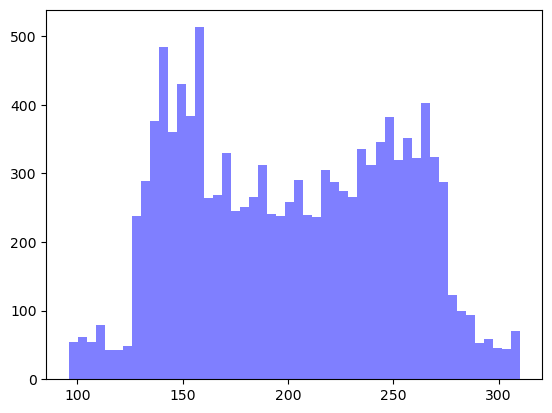

```python
# deeper look at the distribution comparison within one of the "stronger" features
plt.hist(train_df['average_montly_hours'], bins=50, color='blue', alpha = 0.5)
#plt.hist(train_df[train_df["left"] ==1]["satisfaction_level"], bins=50, color='red', alpha = 0.5)
plt.show()
```

```python
lr = LinearRegression()
rf = RandomForestRegressor()

# Train models on training data
lr.fit(X_train, y_train)
rf.fit(X_train, y_train)
```

```
RandomForestRegressor()
```

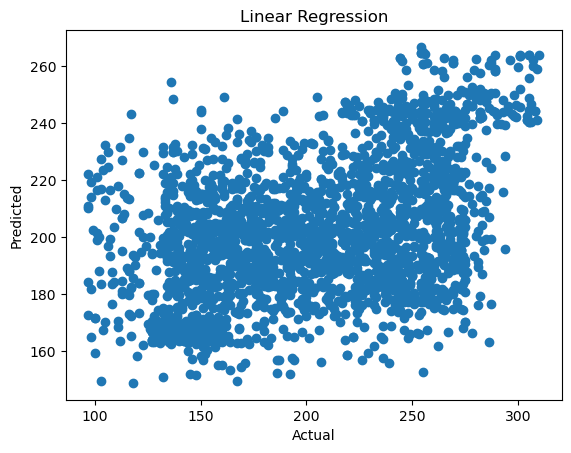

```python
plt.scatter(y_test, lr.predict(X_test))
plt.xlabel('Actual')
plt.ylabel('Predicted')
plt.title('Linear Regression')
plt.show()
```

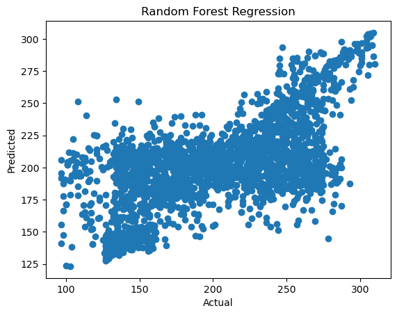

```python
plt.scatter(y_test, rf.predict(X_test))
plt.xlabel('Actual')
plt.ylabel('Predicted')
plt.title('Random Forest Regression')
plt.show()
```

```python
from sklearn.metrics import mean_squared_error

lr_train_mse = mean_squared_error(y_train, lr.predict(X_train))
lr_test_mse = mean_squared_error(y_test, lr.predict(X_test))

rf_train_mse = mean_squared_error(y_train, rf.predict(X_train))
rf_test_mse = mean_squared_error(y_test, rf.predict(X_test))

print('Linear Regression Train MSE:', lr_train_mse)
print('Linear Regression Test MSE:', lr_test_mse)

print('Random Forest Regression Train MSE:', rf_train_mse)
print('Random Forest Regression Test MSE:', rf_test_mse)
```

```
Linear Regression Train MSE: 1919.7190605232722
Linear Regression Test MSE: 1989.2996353149415
Random Forest Regression Train MSE: 212.3828750457954
Random Forest Regression Test MSE: 1548.8061457034637
```

## Results Analysis

Based on the plots and the MSE, I would choose the Random Forest Regression model. The scatter plot for the Random Forest Regression model shows a more linear relationship between the actual and predicted values, indicating that the model is performing better than the Linear Regression model. Additionally, the MSE for the Random Forest Regression model is lower than the MSE for the Linear Regression model on both the training and testing data, which further supports the choice of the Random Forest Regression model. It is worth mentioning that this is not neceseraly a good result as the diffrence between the RFR train and test MSE is very large meaning the model overfitted even though the test MSE is lower than the one in the LR.